# Recommending web-pages to hosts

[figure not shown]

# 3. Recommendation system - up to Collaborative Filtering

[figure not shown]

## Read DataFrame and prepare it for training

First I read the DataTable from the saved parquet files and check columns and Schema

```python
sqlContext = SQLContext(sc)
accessLogs_DF = sqlContext.read.load("accessLogs.parquet", format="parquet").cache()
print "Columns:",  accessLogs_DF.columns
print "Statistic of numeric columns:"
accessLogs_DF.describe().show()
print "Schema of the DataTable"
accessLogs_DF.printSchema()
```

```
Columns: ['content_size', 'date_time', 'host', 'method', 'request', 'response_code']
Statistic of numeric columns:
+-------+-----------------+------------------+
|summary|     content_size|     response_code|
+-------+-----------------+------------------+
|  count|          1673716|           1673716|
|   mean|  8684.2054601856|213.97359767128953|
| stddev|36530.22411160573| 41.84922941436038|
|    min|                0|               200|
|    max|          5597650|               500|
+-------+-----------------+------------------+

Schema of the DataTable
root
 |-- content_size: long (nullable = true)
 |-- date_time: timestamp (nullable = true)
 |-- host: string (nullable = true)
 |-- method: string (nullable = true)
 |-- request: string (nullable = true)
 |-- response_code: long (nullable = true)
```

For recommendations purposes I am interested in records with "GET" method on "OK"(200) response code

```python
iget200_DF = (accessLogs_DF.drop("content_size")
                         .filter((accessLogs_DF.method=="GET") & (accessLogs_DF.response_code==200))
                         .drop("method").drop("response_code").cache())
iget200_DF.show(5, truncate=False)

# I won't need accessLogs_DF anymore
accessLogs_DF.unpersist()
```

```
+---------------------+-------------------+--------------------------------+
|date_time            |host               |request                         |
+---------------------+-------------------+--------------------------------+
|1995-09-06 18:34:11.0|grail1413.nando.net|/pub/k2/am4x44u/gifs/bgpaper.gif|
|1995-09-06 18:34:12.0|grail1413.nando.net|/pub/k2/am4x44u/gifs/dpbar.gif  |
|1995-09-06 18:34:12.0|filler16.PEAK.ORG  |/pub/listserv/lslib1.html       |
|1995-09-06 18:34:12.0|165.227.94.67      |/pub/lschank/web/myguides.html  |
|1995-09-06 18:34:13.0|165.227.94.67      |/pub/lschank/web/text.gif       |
+---------------------+-------------------+--------------------------------+
only showing top 5 rows
```

```
DataFrame[content_size: bigint, date_time: timestamp, host: string, method: string, request: string, response_code: bigint]
```

### Generate integer IDs for hosts and requests

Since pyspark methods work with integer IDs for "host" ("user") and "request" ("item"), I generate those

##### Technical challenges and details to overcome those

The problem is to create an *integer* id for each host (and then each request). I need *integer* because this is the only type that ALS algorithm accepts.

This spark DataFrame unique id can be done created with pyspark.sql.functionsmonotonically*increasing_id(). It generates, however, the 64-bit _long* type in the whole range of possible values, so that there is no way to conver these to 32-bit integer with garantie of keeping the unique property. This is rather inconsistency inside spark which hopefully will be fixed sometime.

The way around that I use here is through RDD using zipWithIndex. Another way through pandas data frame (if hosts and their ids fit in memory) is also possible

```python
import pyspark.sql.functions as func
from pyspark.sql.types import *
#host_id_DF = iget200_DF.select("host")
#                       .dropDuplicates()
#                       .withColumn("user", func.monotonically_increasing_id())
#                       .cache())

host_id_RDD = iget200_DF.select("host").rdd.map(lambda x: x.host).distinct().zipWithIndex()

schema = StructType([StructField("host", StringType(), False),  StructField("user", IntegerType(), False)])
host_id_DF = sqlContext.createDataFrame(host_id_RDD, schema)

host_id_DF.sort("user", ascending=False).show(5)
host_id_DF.printSchema()
```

```
+--------------------+-----+
|                host| user|
+--------------------+-----+
|        38.13.121.26|90866|
|   thale.aimtech.com|90865|
|ad34-157.compuser...|90864|
| wwwsv1.u-aizu.ac.jp|90863|
|modem32.intercom.net|90862|
+--------------------+-----+
only showing top 5 rows

root
 |-- host: string (nullable = false)
 |-- user: integer (nullable = false)
```

```python
#request_id = (iget200_DF.select("request")
#           .dropDuplicates()
#           .withColumn("item", func.monotonically_increasing_id())
#           .cache())

request_id_RDD = iget200_DF.select("request").rdd.map(lambda x: x.request).distinct().zipWithIndex()

schema =  StructType([StructField("request", StringType(), False),  StructField("item", IntegerType(), False)])
request_id_DF = sqlContext.createDataFrame(request_id_RDD, schema)

request_id_DF.sort("item", ascending=False).show(5)
request_id_DF.printSchema()
```

```
+--------------------+-----+
|             request| item|
+--------------------+-----+
|/pub/k2/am4x44u/g...|24321|
| /pub/stc/career.pdf|24320|
|/pub/chinatom/jes...|24319|
|/pub/jellybn/micr...|24318|
|/pub/k2/cgi-bin/i...|24317|
+--------------------+-----+
only showing top 5 rows

root
 |-- request: string (nullable = false)
 |-- item: integer (nullable = false)
```

Now replace "host" and "request" columns with their ids called respectively "users" and "items"

```python
get200_DF = (iget200_DF.join(func.broadcast(host_id_DF),"host").drop("host") # replace host with user
                       .join(func.broadcast(request_id_DF), "request").drop("request") # replace request with item
                       .cache())
get200_DF.show(5)
get200_DF.printSchema()

# I won't need iget200_DF anymore
iget200_DF.unpersist()
```

```
+--------------------+-----+-----+
|           date_time| user| item|
+--------------------+-----+-----+
|1995-09-06 18:34:...|38262| 1718|
|1995-09-06 18:34:...|38262| 9022|
|1995-09-06 18:34:...|28243| 7844|
|1995-09-06 18:34:...|30968| 7978|
|1995-09-06 18:34:...|30968|21532|
+--------------------+-----+-----+
only showing top 5 rows

root
 |-- date_time: timestamp (nullable = true)
 |-- user: integer (nullable = false)
 |-- item: integer (nullable = false)
```

```
DataFrame[date_time: timestamp, host: string, request: string]
```

### Train / validation / test split

```python
from datetime import datetime
threshold_date1 = datetime.strptime("1995/09/10 00:00:00", "%Y/%m/%d %H:%M:%S")
threshold_date2 = datetime.strptime("1995/09/09 00:00:00", "%Y/%m/%d %H:%M:%S")
test =  get200_DF.filter(get200_DF.date_time > threshold_date2).drop("date_time").repartition(8).cache()
validation = (get200_DF.filter((get200_DF.date_time > threshold_date2) & (get200_DF.date_time > threshold_date1))
                       .drop("date_time").repartition(8).cache())
train = get200_DF.filter(get200_DF.date_time < threshold_date2).drop("date_time").repartition(8).cache()
train.show(5)

get200_DF.unpersist()
```

```
+-----+-----+
| user| item|
+-----+-----+
|28243| 7844|
|34048|14643|
|86299| 9825|
|87908| 6688|
|30968| 5407|
+-----+-----+
only showing top 5 rows
```

```
DataFrame[date_time: timestamp, user: int, item: int]
```

At this notebook I am aiming at using the Collaborative Filtering method. This model is reasonable to apply when each host issued at least some minimal (let us say, 10) number of items. The same for items, each should come from at least 10 hosts. The specific numbers and order of selection are determined by business strategy.

```python
train_items_DF = (train.groupBy("item")
                          .agg(func.countDistinct("user").alias("count_h"))
                          .filter("count_h>10")
                          .select("item")
                          .cache())
#train_items_DF.show(5)

train_users_DF = (train.join(train_items_DF, "item")
                       .groupBy("user")
                       .agg(func.countDistinct("item").alias("count_r"))
                       .filter("count_r>10")
                       .select("user")
                       .cache())
#train_users_DF.show(5)

print "Total unique users:", train_users_DF.count() #27191 #23251
print "Total unique items:", train_items_DF.count() # 6595 #6110
```

```
Total unique users: 23251
Total unique items: 6110
```

```python
def prepare_DF_for_CFmodel(dataFrame, train_items_DF=train_items_DF, train_users_DF=train_users_DF):
    """
    Prepares data frame for using with collaborative filtering model
    --- keeps only users from train_users_DF (hosts with more than 10 unique requests)
    --- keeps only items from train_items_DF (requests issued by more than 10 unique hosts)
    --- calculates "rating" as log(1+count)

    Input:
        * dataFrame - spark DataFrame of (user, item, count)
        * train_items_DF - requests issued by more than 10 unique hosts
        * train_users_DF - hosts with more than 10 unique requests

    Output:
        * spark DataFrame of (user, item, rating)
    """

    forCF_DF = (dataFrame.join(func.broadcast(train_items_DF), "item")
                       .join(func.broadcast(train_users_DF), "user")
                       #.dropDuplicates().withColumn("rating", func.lit(float(1)))
                       #.groupBy("user", "item").count().withColumnRenamed("count", "rating")
                       .groupBy("user", "item").count().withColumn("rating", func.log1p("count")).drop("count"))

    return forCF_DF
```

```python
train_forCF_DF = prepare_DF_for_CFmodel(train).cache()
validation_forCF_DF = prepare_DF_for_CFmodel(validation).cache()
test_forCF_DF = prepare_DF_for_CFmodel(test).cache()
```

```python
train.unpersist()
validation.unpersist()
test.unpersist()
```

```
DataFrame[user: int, item: int]
```

## Collaborative filtering with default parameters

In Spark model-based Collaborative Filtering is implemented via Alternating Least Squares (ALS) matrix factorization

```python
from pyspark.ml.recommendation import ALS
als = ALS(implicitPrefs=True)
model_CF = als.fit(train_forCF_DF)
```

```python
#print "User Factors"
#model_CF.userFactors.show(6, truncate=False)
#model.userFactors.orderBy("id").collect()

#print "Item Factors"
#model_CF.itemFactors.show(6, truncate=False)
```

Predict rating to train, validation (which in this case serves as the second test set) and test sets

```python
predi_CF_train_DF = model_CF.transform(train_forCF_DF)
print "This is how the Data Frame with predictions looks like"
predi_CF_train_DF.show(5)
predi_CF_validation_DF = model_CF.transform(validation_forCF_DF)
predi_CF_test_DF = model_CF.transform(test_forCF_DF)
```

```
This is how the Data Frame with predictions looks like
+-----+----+------------------+------------+
| user|item|            rating|  prediction|
+-----+----+------------------+------------+
|35656| 631|0.6931471805599453| 0.033147525|
|68657| 631|0.6931471805599453|  0.01960793|
|73863| 631|0.6931471805599453|5.6201336E-4|
|73869| 631|0.6931471805599453|0.0015009369|
|54876| 631|0.6931471805599453|0.0028627159|
+-----+----+------------------+------------+
only showing top 5 rows
```

## Evaluation with Ranking Metrics

By the construction of the algorithm, ALS internally minimizes MSE. This is, however, not appropriate metric for collaborative filtering. The recommendation tast by its nature is a ranking task. Therefore, I use ranking metrics.

First I convert Data Frame with predictions to RDD suitable for usage with RankingMetrics implemented in pyspark.

```python
def prepare_predictionDF_forRankingMetrics(predictionDF):
    """
    Converts prediction DataFrame (obtained from als_model.transform(dataset))
    to RDD suitable for calculating Ranking Metrics
    """

    #TODO: intelligent threshold

    from operator import itemgetter

    foo = (predictionDF.filter("prediction > 0.4").rdd
                 .map(lambda rec: (rec.user, [(rec.item, rec.rating, rec.prediction)]))
                 .reduceByKey(lambda p,q: p+q)
                 .mapValues(lambda v: ( [g[0] for g in sorted(v, key=itemgetter(2), reverse=True)],
                                        [g[0] for g in sorted(v, key=itemgetter(1), reverse=True)]  ) )
                 .values()
          )
    return foo
```

```python
predi_CF_train_RDD = prepare_predictionDF_forRankingMetrics(predi_CF_train_DF).cache()
predi_CF_validation_RDD = prepare_predictionDF_forRankingMetrics(predi_CF_validation_DF).cache()
predi_CF_test_RDD = prepare_predictionDF_forRankingMetrics(predi_CF_test_DF).cache()

#print "\n\n".join([str(i) for i in predi_CF_validation_RDD.take(3)])
```

Now calculate the metrics

```python
from pyspark.mllib.evaluation import RankingMetrics
metrics_train = RankingMetrics(predi_CF_train_RDD)
metrics_validation = RankingMetrics(predi_CF_validation_RDD)
metrics_test = RankingMetrics(predi_CF_test_RDD)
```

Summarize metrics in pandas data frame

```python
import pandas as pd
atList = [1,5,10]
summarize_metrics = pd.DataFrame({"train": [metrics_train.precisionAt(i) for i in atList],
                                  "validation": [metrics_validation.precisionAt(i) for i in atList],
                                  "test": [metrics_test.precisionAt(i) for i in atList]},
                                  index=["precision at "+str(i) for i in atList],
                                  columns = ["train", "validation", "test"])
print summarize_metrics
```

```
                    train  validation      test
precision at 1   1.000000    1.000000  1.000000
precision at 5   0.989556    0.849761  0.847645
precision at 10  0.935651    0.714833  0.712651
```

and visualize the metrics

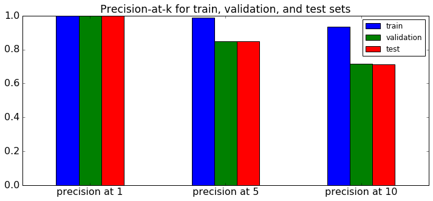

```python
import matplotlib.pyplot as plt
%matplotlib inline

plt.rcParams.update({'axes.titlesize': 'xx-large'})
summarize_metrics.plot.bar(figsize=(12,5),fontsize=16, rot=0,
                           title="Precision-at-k for train, validation, and test sets")
```

```python
# predictions are not needed anymore
predi_CF_train_RDD.unpersist()
predi_CF_validation_RDD.unpersist()
predi_CF_test_RDD.unpersist()
```

```
PythonRDD[617] at RDD at PythonRDD.scala:43
```

## Parameter search with validation set

Since I found it reasonable to recommend few pages, let us say 5, the metric I choose is precision at 5.

```python
#from pyspark.ml.recommendation import ALS
metric_in_use_best = 0.
parameters_best = dict()
collect_info = dict()

for alpha in (5.0, ):
    for regParam in (0.1, 1.0):
        for rank in (3, 5, 9):

                print "alpha", alpha,  "regParam", regParam,  "rank", rank

                #define model with parameters
                als = ALS(rank=rank, maxIter=5, implicitPrefs=True, regParam=regParam,
                          alpha=alpha, nonnegative=False)
                #train model
                model = als.fit(train_forCF_DF)
                # make predictions for validation set
                predi_validation_DF = model.transform(validation_forCF_DF)
                ##### predi_validation_DF.describe().show() # for debugging

                #evaluate predictions for validation set according to the choosen metric
                predi_validation_RDD = prepare_predictionDF_forRankingMetrics(predi_validation_DF)
                metrics_validation = RankingMetrics(predi_validation_RDD)
                metric_in_use =  metrics_validation.precisionAt(5)
                print metric_in_use, "\n\n"
                collect_info.update({'alpha':alpha, "regParam":regParam, "rank":rank, "precision_at5":metric_in_use})

                # mark as "best" the model with the highest metric
                if metric_in_use > metric_in_use_best:
                    metric_in_use_best = metric_in_use
                    parameters_best = als.extractParamMap()
```

```
alpha 5.0 regParam 0.1 rank 3
0.823880597015


alpha 5.0 regParam 0.1 rank 5
0.824948024948


alpha 5.0 regParam 0.1 rank 9
0.800392156863


alpha 5.0 regParam 1.0 rank 3
0.843157894737


alpha 5.0 regParam 1.0 rank 5
0.8305


alpha 5.0 regParam 1.0 rank 9
0.827227722772
```

```python
print "The best parameters found are"
best = {k.name:v   for k,v in parameters_best.items()}
best
```

```
The best parameters found are
```

```
{'alpha': 5.0,
 'checkpointInterval': 10,
 'implicitPrefs': True,
 'itemCol': 'item',
 'maxIter': 5,
 'nonnegative': False,
 'numItemBlocks': 10,
 'numUserBlocks': 10,
 'predictionCol': 'prediction',
 'rank': 3,
 'ratingCol': 'rating',
 'regParam': 1.0,
 'seed': None,
 'userCol': 'user'}
```

### Retrain model with best parameters

After the best hyperparameter set is found by comparing performance on validation set, the performance should be finally checked on the test set

```python
als_optim = ALS()
del best["predictionCol"]
als_optim.setParams(**best)
```

```
ALS_48c6a7d78c92c9a90bc3
```

```python
model_optim = als_optim.fit(train_forCF_DF)
```

```python
predi_optim_test_DF = model_optim.transform(test_forCF_DF)
predi_optim_test_RDD = prepare_predictionDF_forRankingMetrics(predi_optim_test_DF).cache()
metrics_optim_test = RankingMetrics(predi_optim_test_RDD)
```

Add this result to summarize_metrics pandas data frame

```python
summarize_metrics["test_from_optimized"] = [metrics_optim_test.precisionAt(1),
                                            metrics_optim_test.precisionAt(5),
                                            metrics_optim_test.precisionAt(10)]
```

and visualize

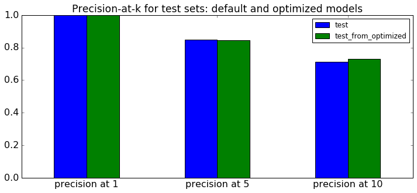

```python
summarize_metrics[["test", "test_from_optimized"]].plot.bar(figsize=(12,5),fontsize=16, rot=0,
                           title="Precision-at-k for test sets: default and optimized models")
```